# reetuthimmaiah400@gmail.com_1

```python
import warnings
warnings.filterwarnings("ignore")
```

```python
import pandas as pd
import numpy as np
import matplotlib.pyplot as plt
import seaborn as sns
```

```python
#importing dataset
haber = pd.read_csv('haberman.csv')
```

```python
haber.info()
```

```
<class 'pandas.core.frame.DataFrame'>
RangeIndex: 306 entries, 0 to 305
Data columns (total 4 columns):
age       306 non-null int64
year      306 non-null int64
nodes     306 non-null int64
status    306 non-null int64
dtypes: int64(4)
memory usage: 9.6 KB
```

```python
#how many rows and colunms?
print(haber.shape)
```

```
(306, 4)
```

306 rows and 4 columns

```python
print(haber.columns)
```

```
Index(['age', 'year', 'nodes', 'status'], dtype='object')
```

```python
haber["status"].value_counts()
```

```
1    225
2     81
Name: status, dtype: int64
```

225 survived more than 5 years and 81 dead within 5 years

Imbalanced dataset

```python
haber.describe()
```

|  | age | year | nodes | status |
| --- | --- | --- | --- | --- |
| count | 306.000000 | 306.000000 | 306.000000 | 306.000000 |
| mean | 52.457516 | 62.852941 | 4.026144 | 1.264706 |
| std | 10.803452 | 3.249405 | 7.189654 | 0.441899 |
| min | 30.000000 | 58.000000 | 0.000000 | 1.000000 |
| 25% | 44.000000 | 60.000000 | 0.000000 | 1.000000 |
| 50% | 52.000000 | 63.000000 | 1.000000 | 1.000000 |
| 75% | 60.750000 | 65.750000 | 4.000000 | 2.000000 |
| max | 83.000000 | 69.000000 | 52.000000 | 2.000000 |

min age of patinets who got operated is 30 max age of patients who got operated is 83

Max no of auxillary in each patients is 52 75% patients have 4 auxillary nodes 25% patients have 0 auxillary nodes 50% patients have 1 auxillary nodes

```python
haber.head()
```

|  | age | year | nodes | status |
| --- | --- | --- | --- | --- |
| 0 | 30 | 64 | 1 | 1 |
| 1 | 30 | 62 | 3 | 1 |
| 2 | 30 | 65 | 0 | 1 |
| 3 | 31 | 59 | 2 | 1 |
| 4 | 31 | 65 | 4 | 1 |

1 : survivied more than 5 years 2 : died within 5 years

### 2-D scatter plot

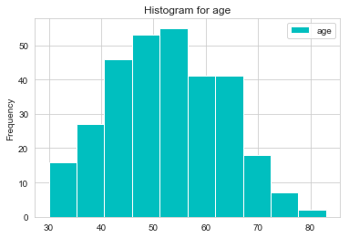

```python
#what is the avreage age of patients who got operated?
haber.age.plot(kind = 'hist', title = 'Histogram for age',x = 'age',y='frequency' ,color = 'c',legend=('x','y'));
```

1) People between age 50 to 55 are more prone to breast cancer

2) Min age of patient who got operated is 30

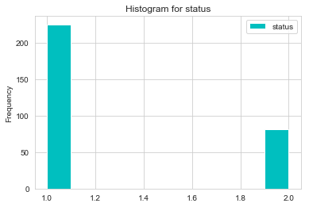

```python
#how many survied and dead?
haber.status.plot(kind = 'hist', title = 'Histogram for status',x = 'status',y='frequency' ,color = 'c', legend = ('x','y'));
```

1) Around 200 patients survived

2) Around 80 patienst are dead

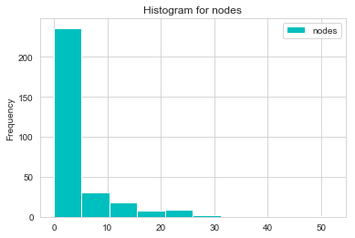

```python
#how many patienst have max auxillary nodes
haber.nodes.plot(kind = 'hist', title = 'Histogram for nodes',x = 'nodes',y='frequency' ,color = 'c',legend = ('x','y') );
```

1) Around 200 patients have 0 to 5 auxillary nodes

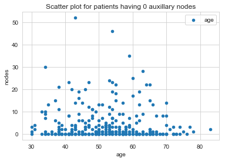

```python
#how many patients have 0 auxillary nodes
haber.plot(kind='scatter',x = 'age',y='nodes');
plt.title('Scatter plot for patients having 0 auxillary nodes')
plt.legend(['age','nodes'])
plt.show()
```

Most of patients have 0 auxillary nodes

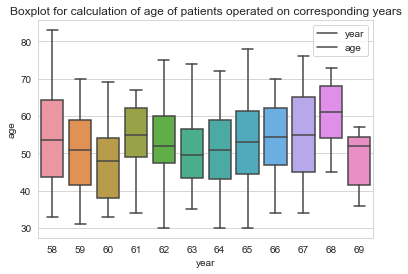

```python
#calculation of age of patients operated on corresponding years
sns.boxplot(x='year' , y='age' , data = haber)
plt.title('Boxplot for calculation of age of patients operated on corresponding years')
plt.legend(['year','age'])
plt.show()
```

Majority of operations were performed on patients whoes age were ranging between 40 & 65

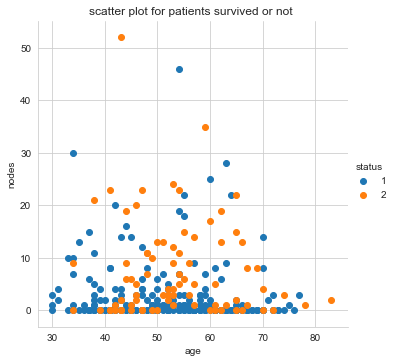

```python
#how many patients survived or not using the color coding with the help of seaborn
sns.set_style("whitegrid");
sns.FacetGrid(haber,hue="status", size=5)\
   .map(plt.scatter,"age","nodes")\
   .add_legend();
plt.title('scatter plot for patients survived or not ')
plt.show()
```

Most of the patients have 0 auxillary nodes

Its impossible to differentiate between surived and dead using 2D scatter plot

Blue points refer to 1 which means survived more than 5 years

Orange points refer to 2 which means dead within 5 years

Since blue points are not easily separable from orange points

we should check all the combinations using Pairplots

### Pair Plots

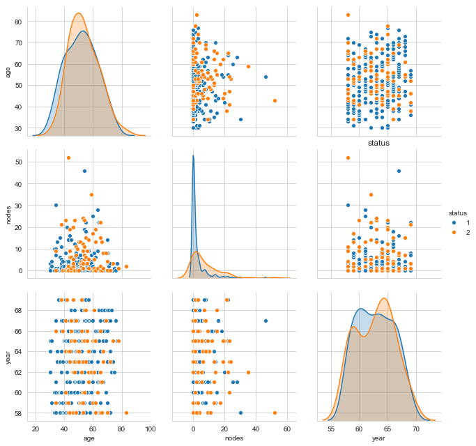

```python
plt.close();
sns.set_style("whitegrid");
sns.pairplot(haber,hue="status",vars = ['age','nodes','year'] ,size=3);
plt.title('status')
plt.show()
```

Diagonal elements are PDF for each feature

Its difficult to distinguish between Blue and Orange scatter plots

### Histogram and PDF

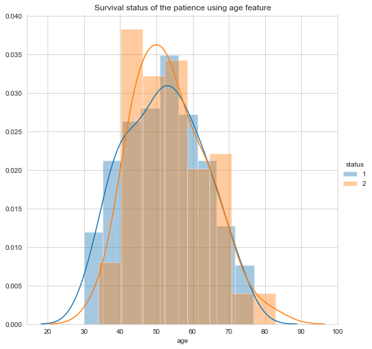

```python
#survival status of the patience usinf age feature
sns.FacetGrid(haber, hue="status" ,size=7)\
   .map(sns.distplot,"age")\
   .add_legend();
plt.title('Survival status of the patience using age feature')
plt.show();
```

Age is not recommended feature to decide the survival status of the patience as we aint able to distinguish between survived and dead

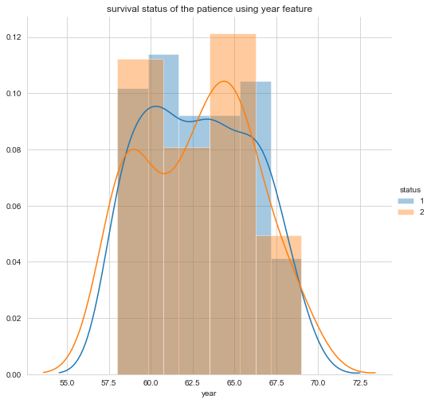

```python
#survival status of the patience usinf year feature
sns.FacetGrid(haber, hue="status" ,size=7)\
   .map(sns.distplot,"year")\
   .add_legend();
plt.title('survival status of the patience using year feature')
plt.show();
```

Year is also not a recommended feature to predict the survival status of the pateints as we aint able to distinguis between survived and dead.

Max no of patients didnt survive in the year 65

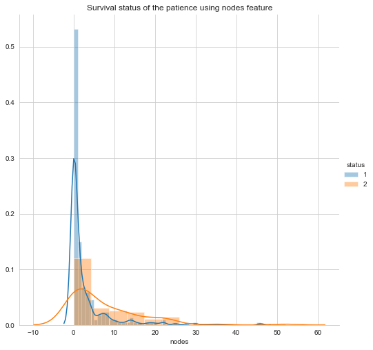

```python
#survival status of the patience usinf nodes feature
sns.FacetGrid(haber, hue="status" ,size=7)\
   .map(sns.distplot,"nodes")\
   .add_legend();
plt.title('Survival status of the patience using nodes feature')
plt.show();
```

We can consider nodes as the only feature to predict survival status of the patients as there is a significant difference between surivied and dead.

Max no of patients who have survivied have zero auxillary nodes

### CDF

```python
# convert 1 & 2 into text format
#survive = 1
#dead = 2
survive = haber.loc[haber["status"]==1]
dead = haber.loc[haber["status"]==2]
```

```
[0.91555556 0.04888889 0.02222222 0.00888889 0.00444444]
[ 0.   9.2 18.4 27.6 36.8 46. ]
```

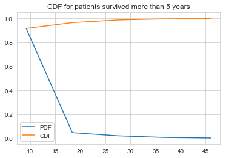

```python
#plotting CDF of nodes
counts,bin_edges =np.histogram(survive['nodes'],bins=5,density=True)
pdf = counts/(sum(counts))
print(pdf);
print(bin_edges)

#compute CDF
cdf = np.cumsum(pdf)
plt.title('CDF for patients survived more than 5 years')
plt.plot(bin_edges[1:],pdf)
plt.plot(bin_edges[1:],cdf)
plt.legend(['PDF','CDF'])
```

Patients having less auxillary nodes have survived more than 5 years

```
[0.71604938 0.18518519 0.07407407 0.01234568 0.01234568]
[ 0.  10.4 20.8 31.2 41.6 52. ]
```

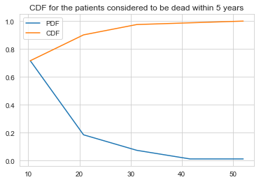

```python
#plotting CDF of nodes
counts,bin_edges =np.histogram(dead['nodes'],bins=5,density=True)
pdf = counts/(sum(counts))
print(pdf);
print(bin_edges)

#compute CDF
cdf = np.cumsum(pdf)
plt.title('CDF for the patients considered to be dead within 5 years')
plt.plot(bin_edges[1:],pdf)
plt.plot(bin_edges[1:],cdf)
plt.legend(['PDF','CDF'])
```

Patients having more auxillary nodes are considered to be dead with 5 years

### Box-plot with whiskers

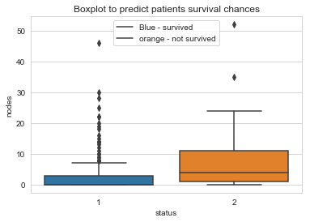

```python
sns.boxplot(x='status',y='nodes',data=haber)
plt.title('Boxplot to predict patients survival chances')
plt.legend(['Blue - survived','orange - not survived'])
plt.show()
```

Patients whose auxillary nodes range from 0 to 5 are prone to survive breast cancer more than 5 years

[figure not shown]

```python
sns.boxplot(x='status',y='age',data=haber)
plt.title('Boxplot to predict patients age of survival chance')
plt.legend(['Blue - s','age'])
plt.show()
```

Patients ranging between age 42 and 60 have survived breast cancer more than 5 years

Patients ranging between age 47 and 61 are dead within 5 years